# Modelos lineares aula 1

Danilo de Paula Santos/Gabriela Wunsch Lopes

17/10/2019

```r
# install.packages("compareGroups")
# install.packages("ggplot2")
# install.packages("data.table")


library("compareGroups")
library("ggplot2")
library("haven")
library("ggpubr")
library("dplyr")
```

# Suwit dataset

## Estudo da relação entre infecção por ancilóstomo e perda de sangue. Tailândia 1970

```r
suwit <- read_sav("Bancos/Suwit.sav")
```

#### Primeiro passo: verificar o banco

```r
compare_suwit <- compareGroups( ~ ., data = suwit)

summary(compare_suwit)
```

```
##
##  --- Descriptives of each row-variable ---
##
## -------------------
## row-variable: Identificação
##
##       N  mean sd       lower    upper
## [ALL] 15 8    4.472136 5.523414 10.47659
##
## -------------------
## row-variable: número de vermes
##
##       N  mean  sd       lower    upper
## [ALL] 15 552.4 513.9007 267.8113 836.9887
##
## -------------------
## row-variable: Perda de sangue por dia
##
##       N  mean     sd       lower    upper
## [ALL] 15 33.45267 24.85249 19.68982 47.21551
```

```r
tabela_suwit <- createTable(compare_suwit)

tabela_suwit
```

```
##
## --------Summary descriptives table ---------
##
## ______________________________________
##                            [ALL]    N
##                            N=15
## ¯¯¯¯¯¯¯¯¯¯¯¯¯¯¯¯¯¯¯¯¯¯¯¯¯¯¯¯¯¯¯¯¯¯¯¯¯¯
## Identificação           8.00 (4.47) 15
## número de vermes         552 (514)  15
## Perda de sangue por dia 33.5 (24.9) 15
## ¯¯¯¯¯¯¯¯¯¯¯¯¯¯¯¯¯¯¯¯¯¯¯¯¯¯¯¯¯¯¯¯¯¯¯¯¯¯
```

#### Segundo passo: verificar linearidade com gráfico de dispersão e identificar pontos

1. Gráfico de dispersão

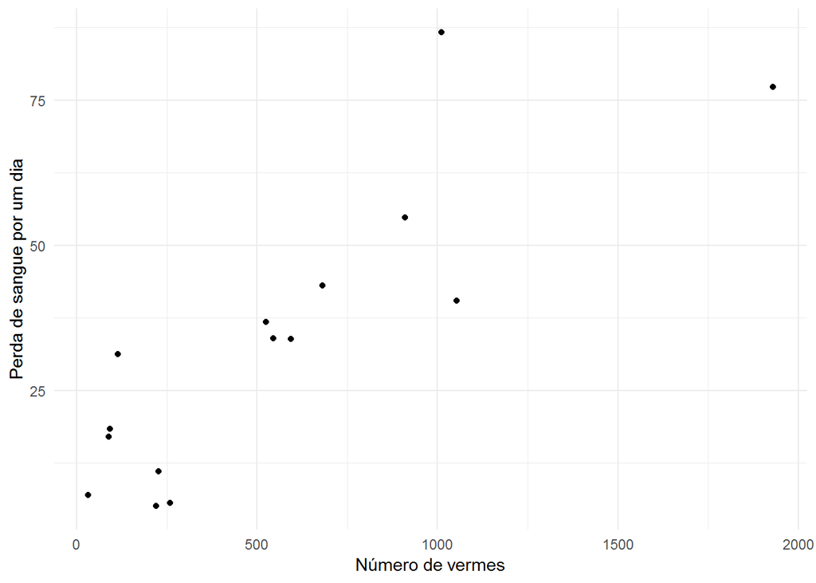

```r
suwit_scatter <- ggplot(suwit, aes(x = vermes, y = perda_sangue))+
  geom_point() +
  scale_x_continuous("Número de vermes") +
  scale_y_continuous("Perda de sangue por um dia") +
  theme_minimal()

suwit_scatter
```

2. Identificando pontos: qual o ID do ponto mais extremo na vertical?

```r
suwit %>%
  filter(perda_sangue>75, vermes<1500)
```

```
## # A tibble: 1 x 3
##      id vermes perda_sangue
##   <dbl>  <dbl>        <dbl>
## 1    13   1012         86.7
```

#### Terceiro passo: estimar modelo

Modelo liner para perda de sangue em função de número de vermes

```r
lm_suwit <- lm(formula = perda_sangue ~ vermes,
                    data = suwit)

summary(lm_suwit)
```

```
##
## Call:
## lm(formula = perda_sangue ~ vermes, data = suwit)
##
## Residuals:
##     Min      1Q  Median      3Q     Max
## -15.846 -10.812   0.750   4.356  34.390
##
## Coefficients:
##              Estimate Std. Error t value Pr(>|t|)
## (Intercept) 10.847327   5.308569   2.043   0.0618 .
## vermes       0.040922   0.007147   5.725 6.99e-05 ***
## ---
## Signif. codes:  0 '***' 0.001 '**' 0.01 '*' 0.05 '.' 0.1 ' ' 1
##
## Residual standard error: 13.74 on 13 degrees of freedom
## Multiple R-squared:  0.716,  Adjusted R-squared:  0.6942
## F-statistic: 32.78 on 1 and 13 DF,  p-value: 6.99e-05
```

Gerando intervalo de confiança para os parâmetros estimados

Intervalo de confiança: estima quanto, em média, é a perda sanguínea de um grupo de pacientes com determinado número de vermes

```r
confint(lm_suwit)
```

```
##                   2.5 %      97.5 %
## (Intercept) -0.62113883 22.31579336
## vermes       0.02548089  0.05636321
```

A cada aumento de 1 verme, ocorre um aumento de 0.04 (95%IC 0.026 - 0.056) na perda de sangue, sendo que 71,6% (Multiple R-squared) da variabilidade da perda de sangue em relação à perda média da amostra é explicada pelo aumento do número de vermes.

Estimando intervalo de predição para cada observação do banco

Intervalo de predição: prediz a perda de sangue para um paciente que apresenta determinado número de vermes

```r
suwit_pred <- predict(lm_suwit, interval = 'predict')
suwit_pred
```

```
##         fit        lwr       upr
## 1  12.15683 -19.543164  43.85683
## 2  14.48939 -16.999013  45.97779
## 3  14.61216 -16.865752  46.09006
## 4  15.51244 -15.890490  46.91537
## 5  19.85018 -11.241030  50.94139
## 6  20.17755 -10.893500  51.24861
## 7  21.44614  -9.551347  52.44362
## 8  32.33140   1.663860  62.99895
## 9  33.14984   2.485006  63.81468
## 10 35.15502   4.483672  65.82638
## 11 38.75616   8.026311  69.48602
## 12 48.12731  16.966765  79.28786
## 13 52.26044  20.785321  83.73556
## 14 53.97917  22.351510  85.60682
## 15 89.78596  52.474437 127.09748
```

Incluindo o intervalo de predição para cada observação do banco

```r
suwit <- cbind(suwit, suwit_pred)
```

Gerando um gráfico contendo intervalo de confiança e intervalo de predição

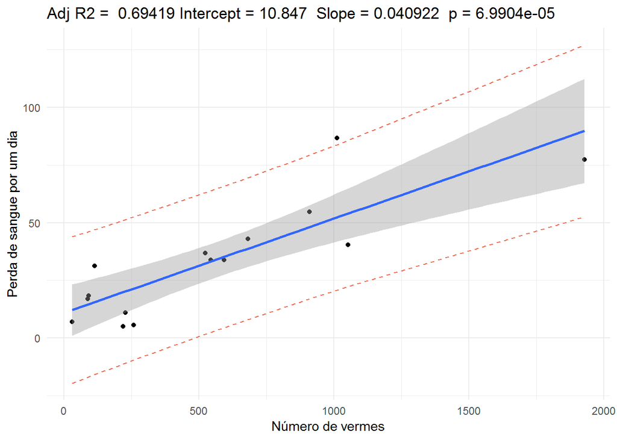

```r
suwit_pred_plot <- ggplot(suwit, aes(x = vermes, y = perda_sangue)) +
                                 geom_point() +
                                 geom_smooth(method = "lm") +
                                 scale_x_continuous("Número de vermes") +
                                 scale_y_continuous("Perda de sangue por um dia") +
                                 theme_minimal() +
                                 geom_line(aes(y = lwr), col = "coral2", linetype = "dashed") +
                                 geom_line(aes(y = upr), col = "coral2", linetype = "dashed") +
  labs(title = paste("Adj R2 = ",signif(summary(lm_suwit)$adj.r.squared, 5),
                         "Intercept =",signif(lm_suwit$coef[[1]],5 ),
                         " Slope =",signif(lm_suwit$coef[[2]], 5),
                         " p =",signif(summary(lm_suwit)$coef[2,4], 5)))




suwit_pred_plot
```

A faixa cinza corresponde ao intervalo de confiança e as linhas laranja são os limites do intervalo de predição.

# Fat_dat dataset

## Estudo Fat_dat “Fitting Percentage of Body Fat to Simple Body Measurements”

```r
fat_dat <- read_sav("Bancos/fat_dat.sav")
```

Corrigindo os erros de digitação:

- The body densities for cases 48, 76, and 96, for instance, each seem to have one digit in error as can be seen from the two body fat percentage values.
- Case 42) over 200 pounds in weight who is less than 3 feet tall (the height should presumably be 69.5 inches, not 29.5 inches)!
- The percent body fat estimates are truncated to zero when negative (case 182)

```r
# Altura

fat_dat$altura_pol <- ifelse( fat_dat$numero == 42, 69.5, fat_dat$altura_pol)

# Densidades

fat_dat$densidade <- ifelse( fat_dat$numero == 48, 1.0865, fat_dat$densidade)
fat_dat$densidade <- ifelse( fat_dat$numero == 76, 1.0566, fat_dat$densidade)
fat_dat$densidade <- ifelse( fat_dat$numero == 96, 1.0591, fat_dat$densidade)
```

```r
compare_fat <- compareGroups( ~ ., data = fat_dat)

summary(compare_fat)
```

```
##
##  --- Descriptives of each row-variable ---
##
## -------------------
## row-variable: numero
##
##       N   mean  sd       lower    upper
## [ALL] 252 126.5 72.89033 117.4569 135.5431
##
## -------------------
## row-variable: fat_Brozek
##
##       N   mean     sd       lower    upper
## [ALL] 252 18.93849 7.750856 17.97689 19.9001
##
## -------------------
## row-variable: fat_Siri
##
##       N   mean     sd      lower    upper
## [ALL] 252 19.15079 8.36874 18.11253 20.18906
##
## -------------------
## row-variable: densidade
##
##       N   mean     sd       lower    upper
## [ALL] 252 1.055455 0.018909 1.053109 1.057801
##
## -------------------
## row-variable: idade
##
##       N   mean     sd       lower    upper
## [ALL] 252 44.88492 12.60204 43.32146 46.44838
##
## -------------------
## row-variable: Peso em libras
##
##       N   mean     sd       lower    upper
## [ALL] 252 178.9244 29.38916 175.2783 182.5706
##
## -------------------
```

[output cut: 61 more lines]

```
##
##       N   mean     sd       lower    upper
## [ALL] 252 32.27341 3.021274 31.89858 32.64825
##
## -------------------
## row-variable: circ do antebraco
##
##       N   mean     sd       lower    upper
## [ALL] 252 28.66389 2.020691 28.41319 28.91458
##
## -------------------
## row-variable: circ do pulso
##
##       N   mean     sd       lower    upper
## [ALL] 252 18.22976 0.933585 18.11394 18.34559
```

```r
tabela_fat <- createTable(compare_fat)
```

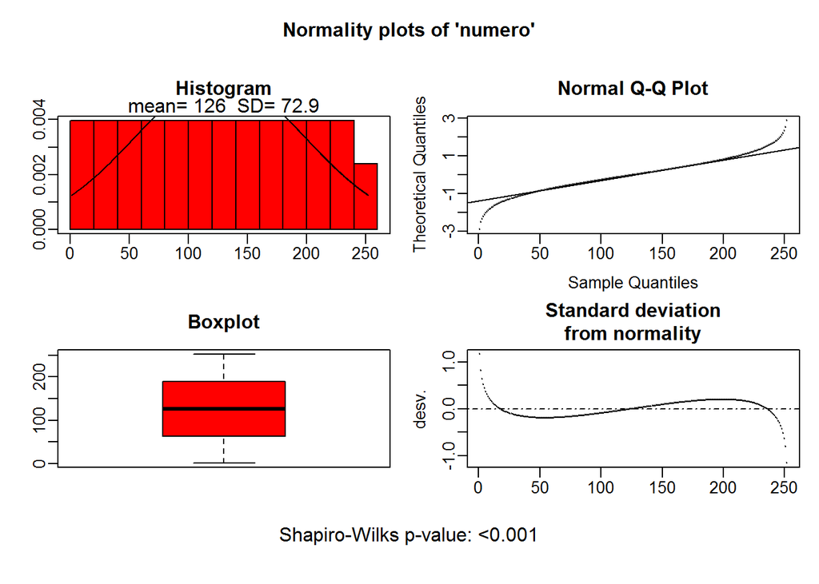

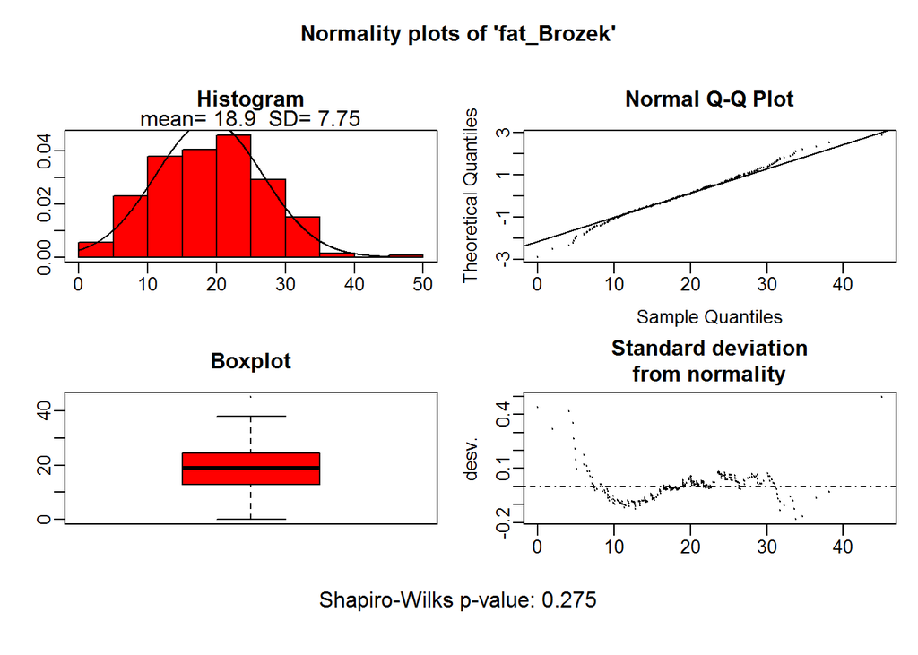

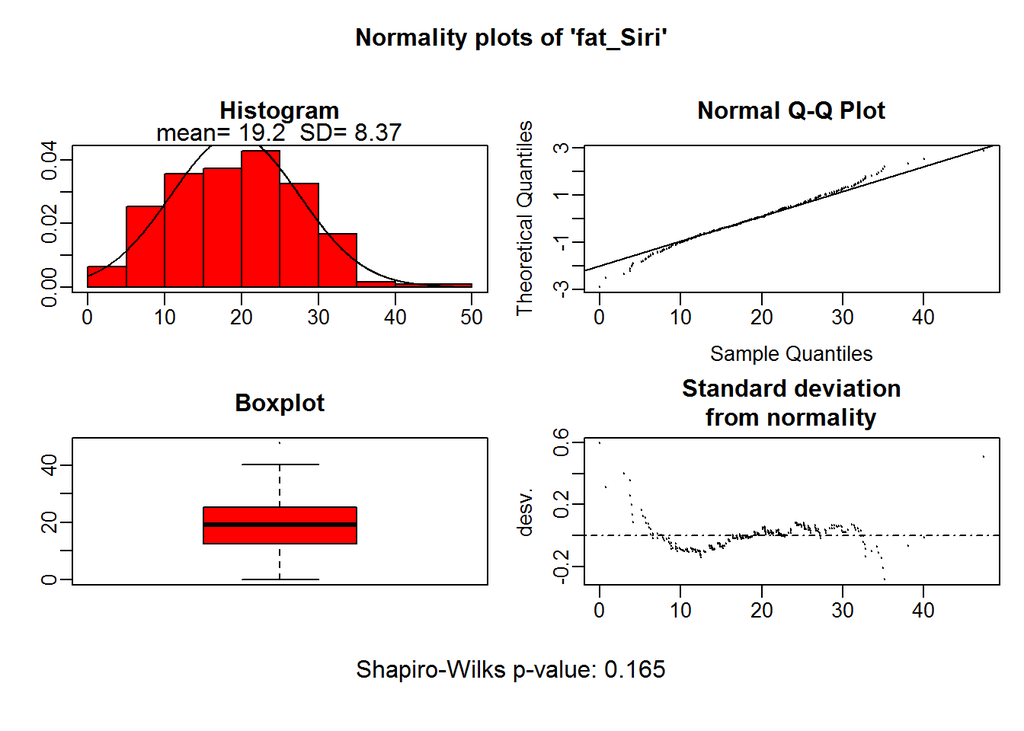

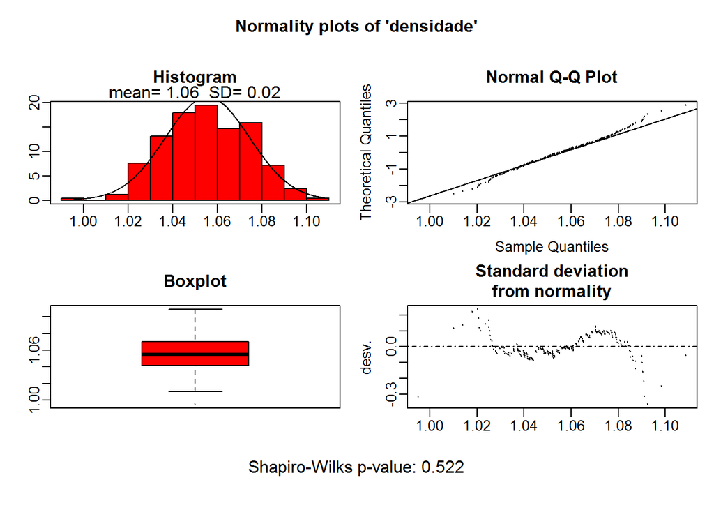

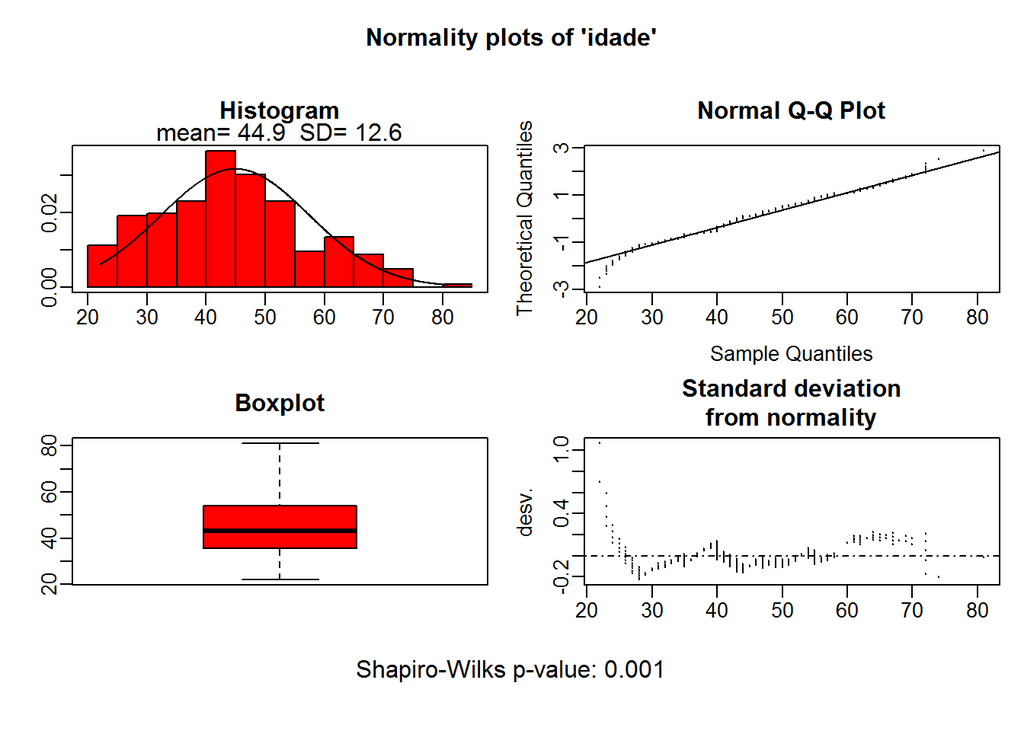

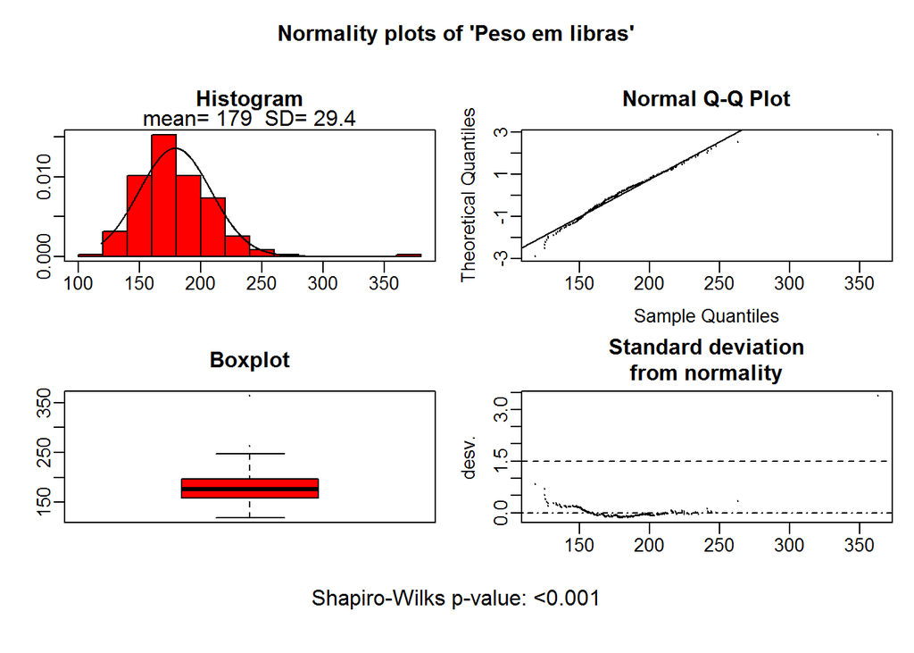

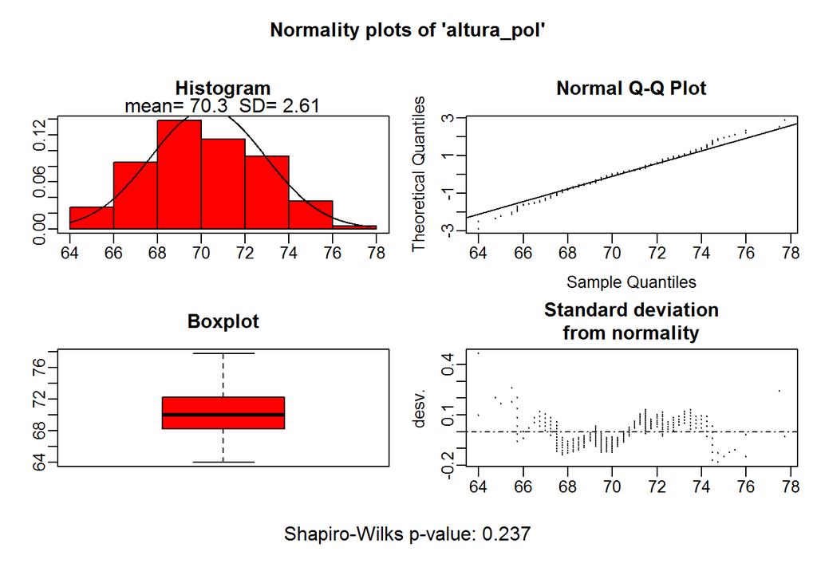

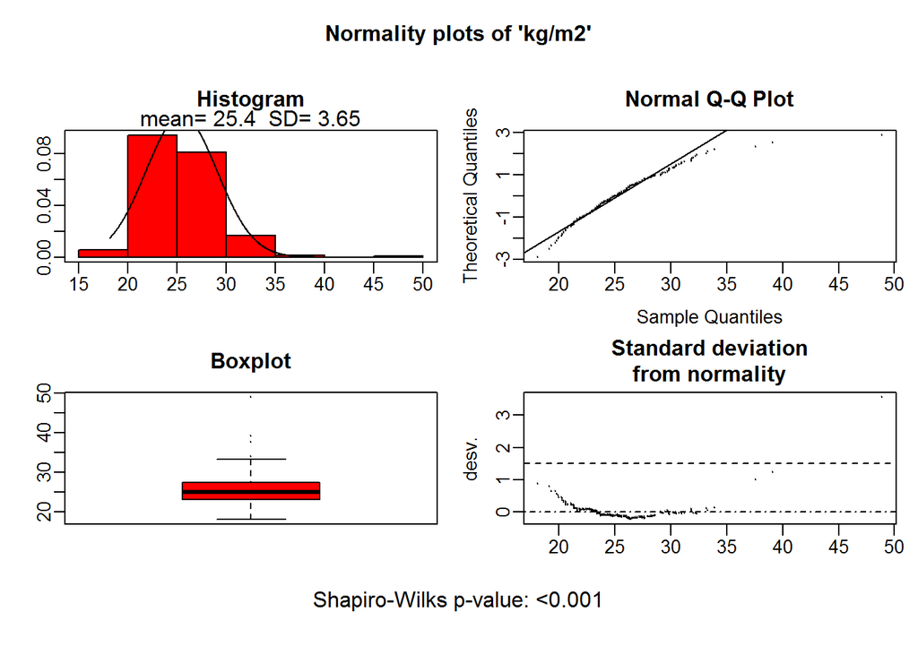

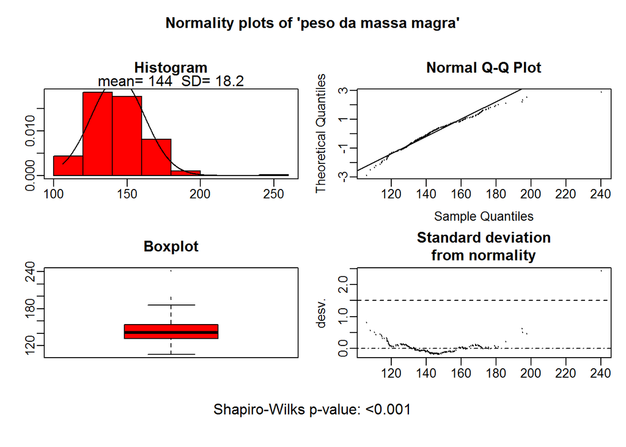

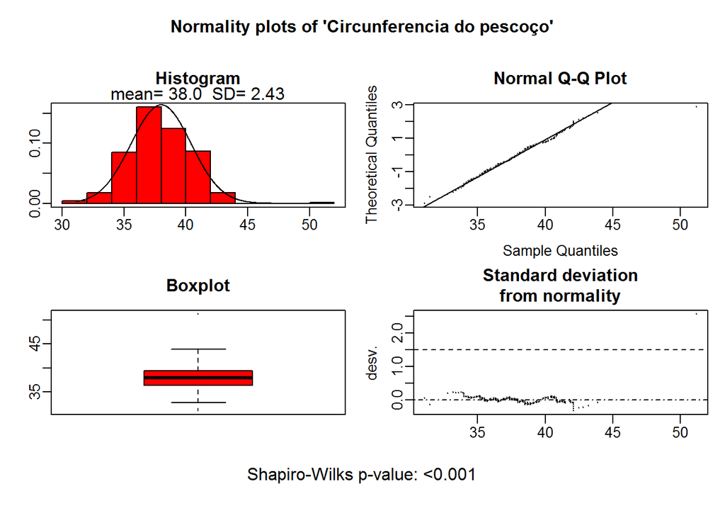

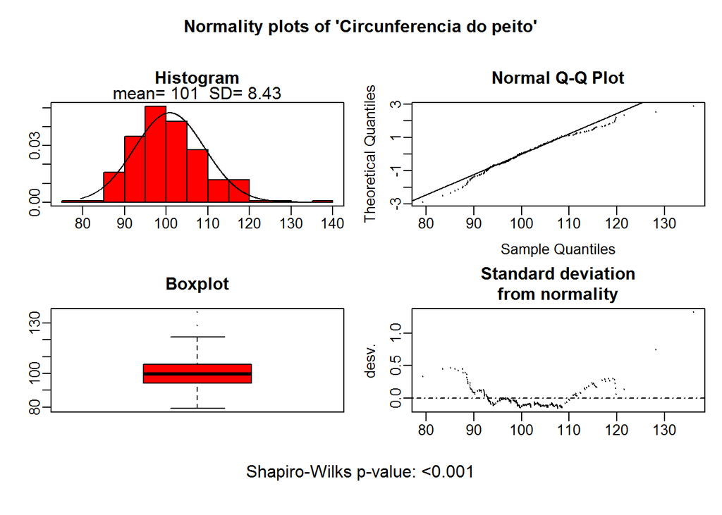

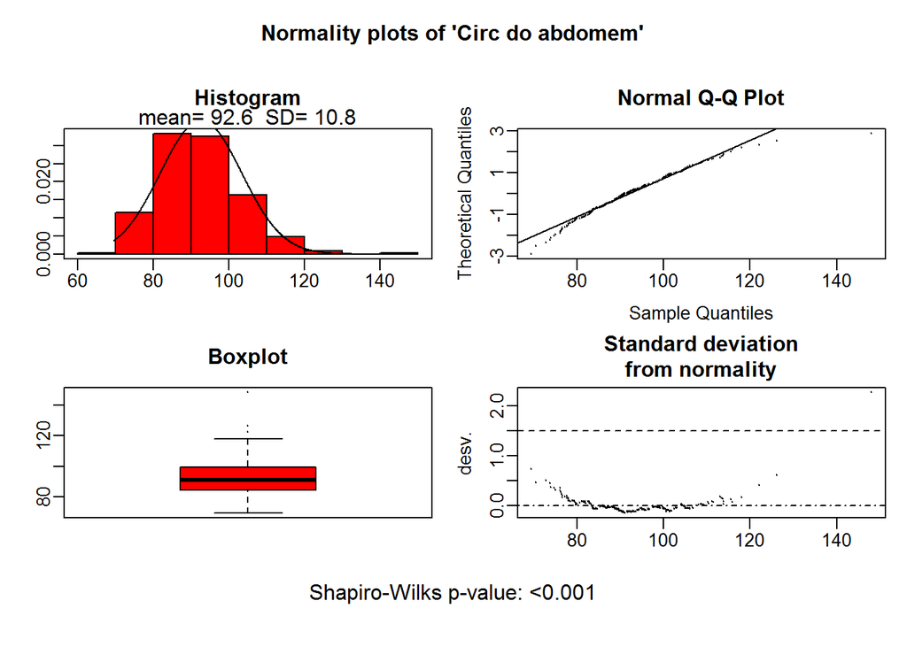

[7 more figures not shown]

```r
plot(compare_fat)
```

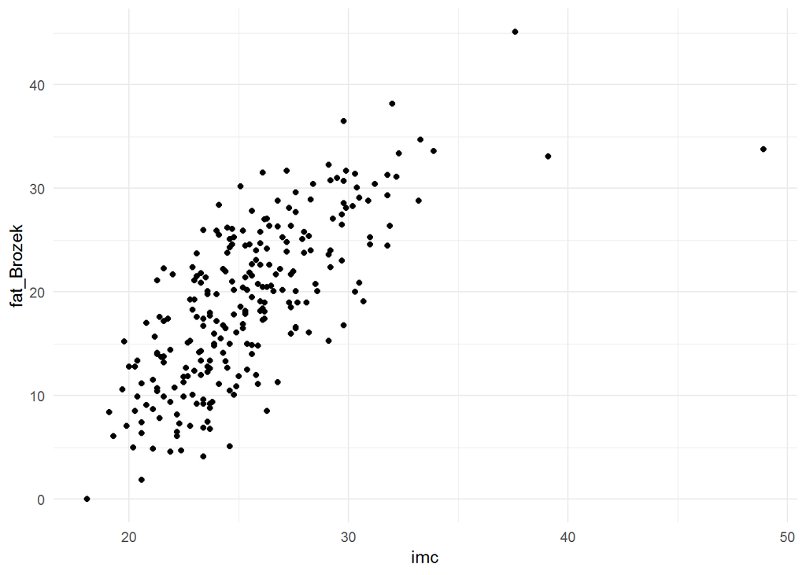

```r
disp_fat_Brozek<- ggplot(fat_dat, aes(x = imc, y = fat_Brozek))+
  geom_point() +
  theme_minimal()

disp_fat_Brozek
```

```r
lm_imc_brozek <- lm(formula = fat_Brozek ~ imc,
                    data = fat_dat)

summary(lm_imc_brozek)
```

```
##
## Call:
## lm(formula = fat_Brozek ~ imc, data = fat_dat)
##
## Residuals:
##      Min       1Q   Median       3Q      Max
## -21.4292  -3.4478   0.2113   3.8663  11.7826
##
## Coefficients:
##              Estimate Std. Error t value Pr(>|t|)
## (Intercept) -20.40508    2.36723   -8.62 7.78e-16 ***
## imc           1.54671    0.09212   16.79  < 2e-16 ***
## ---
## Signif. codes:  0 '***' 0.001 '**' 0.01 '*' 0.05 '.' 0.1 ' ' 1
##
## Residual standard error: 5.324 on 250 degrees of freedom
## Multiple R-squared:   0.53,  Adjusted R-squared:  0.5281
## F-statistic: 281.9 on 1 and 250 DF,  p-value: < 2.2e-16
```

```r
confint(lm_imc_brozek)
```

```
##                  2.5 %    97.5 %
## (Intercept) -25.067331 -15.74283
## imc           1.365275   1.72815
```

A cada aumento de 1 unidade no IMC ocorre aumento de 1.55% na gordura corporal pelo índice Brozek. O intervalo de confiança é de 1.36 a 1.73.

```r
brozek_pred <- predict(lm_imc_brozek, interval = "predict")
dat_brozek <-cbind(fat_dat, brozek_pred)
```

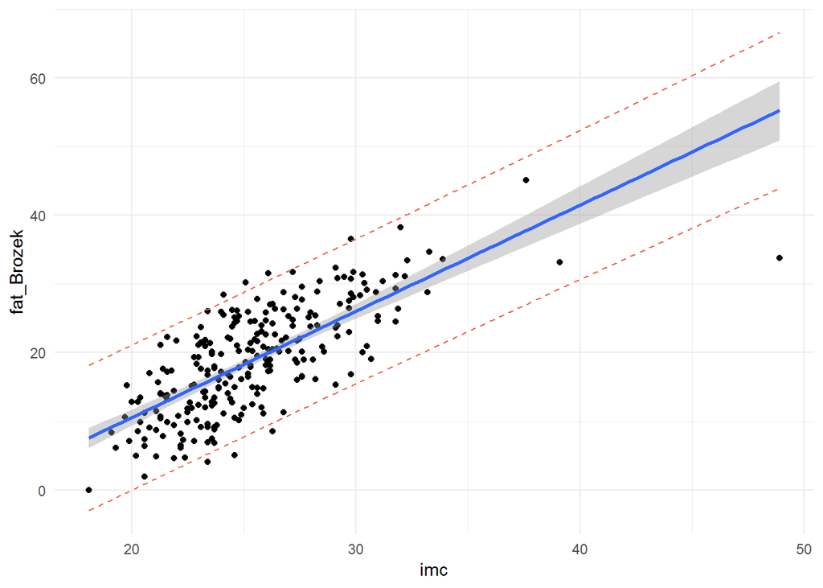

```r
plot_fat_Brozek <- ggplot(dat_brozek, aes(x = imc, y = fat_Brozek))+
  geom_point() +
  geom_smooth (method = "lm",)+
  theme_minimal() +
  geom_line(aes(y = lwr), col = "coral2", linetype = "dashed") +   geom_line(aes(y = upr), col = "coral2", linetype = "dashed")

plot_fat_Brozek
```

```r
lm_imc_siri <- lm(formula = fat_Siri  ~ imc,
                    data = fat_dat)

summary(lm_imc_siri)
```

```
##
## Call:
## lm(formula = fat_Siri ~ imc, data = fat_dat)
##
## Residuals:
##      Min       1Q   Median       3Q      Max
## -23.1070  -3.7418   0.2101   4.2070  12.8114
##
## Coefficients:
##              Estimate Std. Error t value Pr(>|t|)
## (Intercept) -23.29940    2.55796  -9.109   <2e-16 ***
## imc           1.66884    0.09955  16.764   <2e-16 ***
## ---
## Signif. codes:  0 '***' 0.001 '**' 0.01 '*' 0.05 '.' 0.1 ' ' 1
##
## Residual standard error: 5.753 on 250 degrees of freedom
## Multiple R-squared:  0.5292, Adjusted R-squared:  0.5273
## F-statistic:   281 on 1 and 250 DF,  p-value: < 2.2e-16
```

```r
confint(lm_imc_siri)
```

```
##                  2.5 %     97.5 %
## (Intercept) -28.337296 -18.261512
## imc           1.472787   1.864899
```

Para o aumento de 1 ponto no IMC ocorre aumento de 1.7% (95%IC 1.5-1.86) na gordura corporal. O modelo explica 52% da variabilidade da gordura corporal.

```r
siri_pred <- predict(lm_imc_siri, interval = "predict")
dat_siri <-cbind(fat_dat, siri_pred)
```

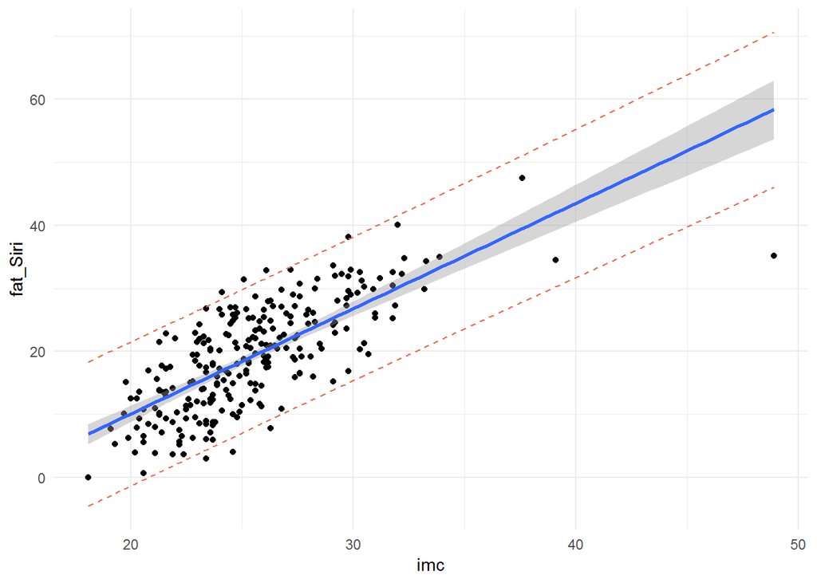

```r
plot_fat_siri <- ggplot(dat_siri, aes(x = imc, y = fat_Siri))+
  geom_point() +
  geom_smooth (method = "lm",)+
  theme_minimal() +
  geom_line(aes(y = lwr), col = "coral2", linetype = "dashed") +   geom_line(aes(y = upr), col = "coral2", linetype = "dashed")

plot_fat_siri
```

# Anscombe dataset

## 4 bancos com formas funcionais diferentes mas estatísticas resumo e linhas de regressão idênticas

```r
anscombe_dataset <- data("anscombe")
```

```r
compare_anscombe <- compareGroups(data = anscombe, ~ x1+
                                     x2+
                                     x3+
                                     x4)

createTable(compare_anscombe)
```

```
##
## --------Summary descriptives table ---------
##
## _________________
##       [ALL]    N
##       N=11
## ¯¯¯¯¯¯¯¯¯¯¯¯¯¯¯¯¯
## x1 9.00 (3.32) 11
## x2 9.00 (3.32) 11
## x3 9.00 (3.32) 11
## x4 9.00 (3.32) 11
## ¯¯¯¯¯¯¯¯¯¯¯¯¯¯¯¯¯
```

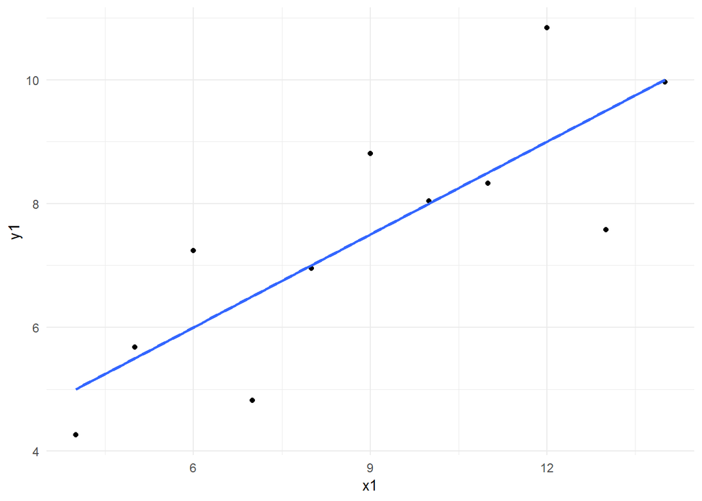

```r
x1_scatter <- ggplot(anscombe, aes(x = x1, y = y1))+
  geom_point() +
  theme_minimal()+
  geom_smooth(method = "lm", se = FALSE)

x1_scatter
```

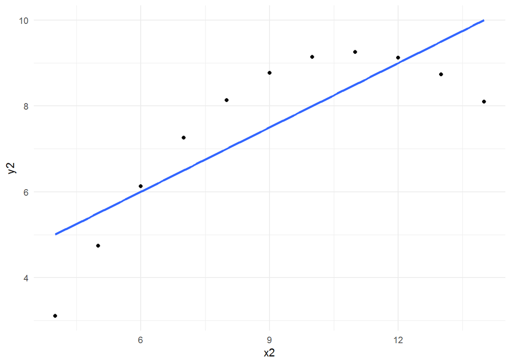

```r
x2_scatter <- ggplot(anscombe, aes(x = x2, y = y2))+
  geom_point() +
  theme_minimal() +
  geom_smooth(method = "lm", se = FALSE)

x2_scatter
```

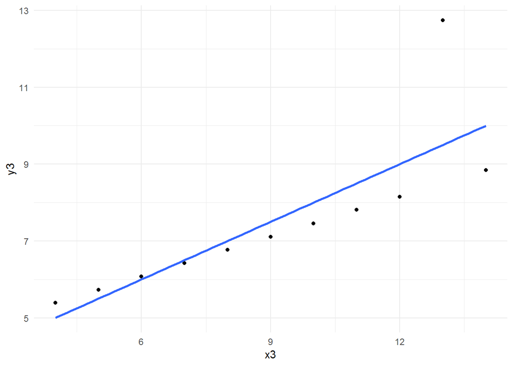

```r
x3_scatter <- ggplot(anscombe, aes(x = x3, y = y3))+
  geom_point() +
  theme_minimal() +
  geom_smooth(method = "lm", se = FALSE)

x3_scatter
```

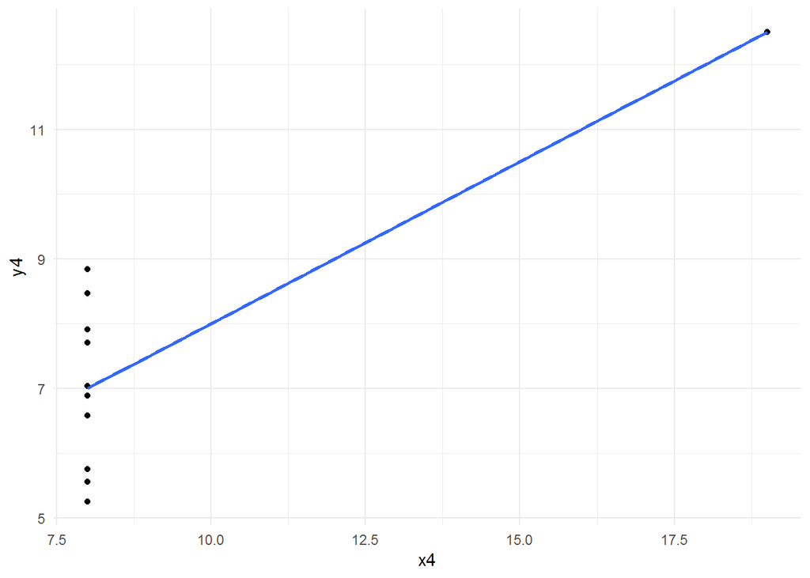

```r
x4_scatter <- ggplot(anscombe, aes(x = x4, y = y4))+
  geom_point() +
  theme_minimal() +
  geom_smooth(method = "lm", se = FALSE)

x4_scatter
```